# Project: Subsetting and Exploring the Alzheimer Data

Zachary Colinco

03/18/26

```r
library(tidyverse)
library(janitor)
library(broom)
library(bayesrules)
library(modelr)
```

Save this file in your project folder inside your class folder. Import the Alzheimer data.

```r
alz <- read_csv("../data/alzheimer_data.csv")
```

Consider the following objectives and corresponding variables and their types:

- Objective 1: Explore the association between the gender of a person and their diagnosis, while also considering other potential confounding variables that might impact this association.

gender:

female (0 = not female, 1 = female) categorical, logical

diagnosis:

diagnosis (0 = normal cognition, 1 = mild cognitive impairment, 2 = dementia due to AD) categorical, factor

potential confounding variables:

age: Subject’s age (years) (18-120) numerical

educ: Subject’s number of years of education (0-36), numerical

- Objective 2: Compare various cognitive tests from the Behavioral Survey Data to MRI Measurement Data in terms of prediction accuracy in the diagnosis of Alzheimer’s disease.

Behavioral Survey Data:

cdrglob: Global Clinical Dementia Rating (CDR) Score (0.0 = No impairment, 0.5 = Questionable impairment, 1.0 = Mild impairment, 2.0 = Moderate impairment, 3.0 = Severe impairment) categorical, factor

MRI Measurement Data:

naccicv: Total intracranial volume (cc) numerical

csfvol: Total brain cerebrospinal fluid volume (cc) numerical

diagnosis:

diagnosis (0 = normal cognition, 1 = mild cognitive impairment, 2 = dementia due to AD) categorical, factor

- Objective 3: Investigate the differences between the left or right parietal lobe cortical gray matter volume and the total frontal lobe cortical gray matter volume in the diagnosis of Alzheimer’s while controlling for gender and other variables such as age and education (pick one).

Cortical gray matter:

lparcort: Segmented left parietal lobe cortical gray matter volume (cc) numerical

rparcort: Segmented right parietal lobe cortical gray matter volume (cc) numerical

frcort: Segmented total frontal lobe cortical gray matter volume (cc) numerical

diagnosis:

diagnosis (0 = normal cognition, 1 = mild cognitive impairment, 2 = dementia due to AD) categorical, factor

female: (0 = not female, 1 = female) categorical, factor

Other variables:

age: Subject’s age (years) (18-120) numerical

educ: Subject’s number of years of education (0-36), numerical

**1. Pick one objective (preferably the one you chose for the previous activity) and subset the `alzheimer` data to include only the variables that relate to your Objective. Note that regardless of which objective you choose, make sure you keep the `id` variable to uniquely identify each observation. Save this new data frame under “alz1heimer1” or “alzheimer2” or “alzheimer3” depending on the objective you chose.**

```r
# controlling for gender, age, educ
alz3 <- alz |>
  select("id", "frcort", "lparcort", "diagnosis", "female", "educ")
glimpse(alz3)
```

```
## Rows: 2,700
## Columns: 6
## $ id        <chr> "S060833", "S932623", "S755478", "S852291", "S011143", "S069…
## $ frcort    <dbl> 160.570, 187.874, 163.214, 165.120, 149.138, 140.220, 195.24…
## $ lparcort  <dbl> 46.7100, 43.1023, 40.1172, 46.0700, 40.2664, 42.9700, 48.740…
## $ diagnosis <dbl> 0, 0, 0, 0, 1, 0, 0, 2, 0, 2, 0, 0, 0, 1, 0, 1, 2, 2, 2, 1, …
## $ female    <dbl> 0, 1, 1, 1, 0, 1, 1, 0, 1, 0, 1, 1, 0, 1, 1, 1, 0, 0, 1, 1, …
## $ educ      <dbl> 12, 16, 18, 20, 14, 16, 16, 17, 18, 13, 16, 16, 17, 20, 13, …
```

**2. Consider the variables involved in your objective from your new data frame. Determine if you need to change the type of variable, say from numerical to factor, or if you need to create new variables. If you do so, make sure to save your changes to your data frame under the same name.**

```r
alz3 <- alz3 |>
  mutate(diagnosis = as.factor(diagnosis),
         female = as.factor(female))
glimpse(alz3)
```

```
## Rows: 2,700
## Columns: 6
## $ id        <chr> "S060833", "S932623", "S755478", "S852291", "S011143", "S069…
## $ frcort    <dbl> 160.570, 187.874, 163.214, 165.120, 149.138, 140.220, 195.24…
## $ lparcort  <dbl> 46.7100, 43.1023, 40.1172, 46.0700, 40.2664, 42.9700, 48.740…
## $ diagnosis <fct> 0, 0, 0, 0, 1, 0, 0, 2, 0, 2, 0, 0, 0, 1, 0, 1, 2, 2, 2, 1, …
## $ female    <fct> 0, 1, 1, 1, 0, 1, 1, 0, 1, 0, 1, 1, 0, 1, 1, 1, 0, 0, 1, 1, …
## $ educ      <dbl> 12, 16, 18, 20, 14, 16, 16, 17, 18, 13, 16, 16, 17, 20, 13, …
```

**3. Create a new variable called “diagnose” using the existing diagnosis variable. Assign normal cognition to “Normal” and mild impairment and dementia due to AD to “Dementia”. Save the new variable to your data frame.**

```r
alz3 <- alz3 |>
  mutate(diagnose = case_when(
    diagnosis == 0 ~ 'Normal',
    diagnosis == 1 | diagnosis == 2 ~ 'Dementia'), .after = 2)
glimpse(alz3)
```

```
## Rows: 2,700
## Columns: 7
## $ id        <chr> "S060833", "S932623", "S755478", "S852291", "S011143", "S069…
## $ frcort    <dbl> 160.570, 187.874, 163.214, 165.120, 149.138, 140.220, 195.24…
## $ diagnose  <chr> "Normal", "Normal", "Normal", "Normal", "Dementia", "Normal"…
## $ lparcort  <dbl> 46.7100, 43.1023, 40.1172, 46.0700, 40.2664, 42.9700, 48.740…
## $ diagnosis <fct> 0, 0, 0, 0, 1, 0, 0, 2, 0, 2, 0, 0, 0, 1, 0, 1, 2, 2, 2, 1, …
## $ female    <fct> 0, 1, 1, 1, 0, 1, 1, 0, 1, 0, 1, 1, 0, 1, 1, 1, 0, 0, 1, 1, …
## $ educ      <dbl> 12, 16, 18, 20, 14, 16, 16, 17, 18, 13, 16, 16, 17, 20, 13, …
```

**4. Find an appropriate numerical summary for each variable individually (skip diagnosis, as the new focus is the variable diagnose). Write a sentence or two to describe your findings.**

```r
alz3 |>
  summarize(mean(frcort), mean(lparcort), median(educ), sd(frcort), sd(lparcort), IQR(educ), min(frcort), max(frcort), min(lparcort), max(lparcort), quantile(educ, 0.75))
```

```
## # A tibble: 1 × 11
##   `mean(frcort)` `mean(lparcort)` `median(educ)` `sd(frcort)` `sd(lparcort)`
##            <dbl>            <dbl>          <dbl>        <dbl>          <dbl>
## 1           171.             46.8             16         23.7           6.53
## # ℹ 6 more variables: `IQR(educ)` <dbl>, `min(frcort)` <dbl>,
## #   `max(frcort)` <dbl>, `min(lparcort)` <dbl>, `max(lparcort)` <dbl>,
## #   `quantile(educ, 0.75)` <dbl>
```

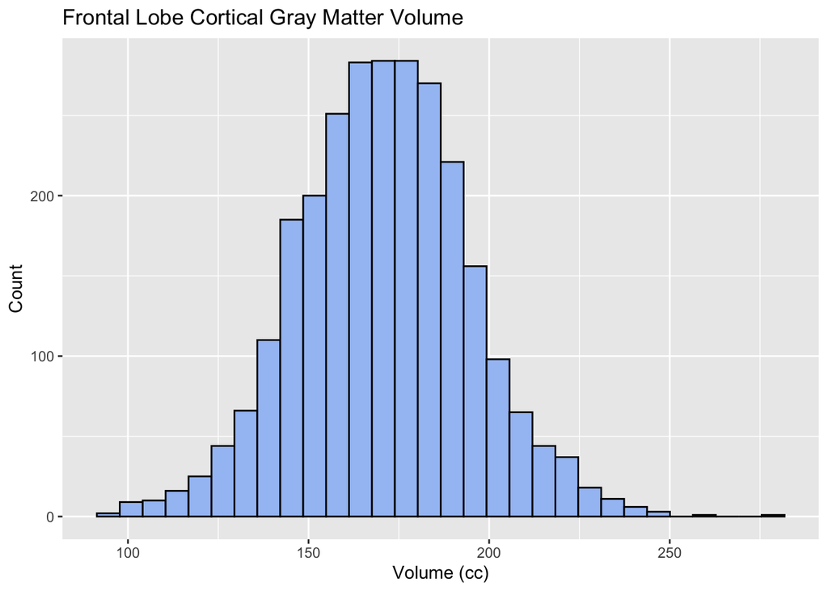

```r
alz3 |>
  ggplot(aes(x = frcort)) + geom_histogram(color = "black", fill = "#a4c2f4") + labs(title = "Frontal Lobe Cortical Gray Matter Volume") + xlab('Volume (cc)') + ylab('Count')
```

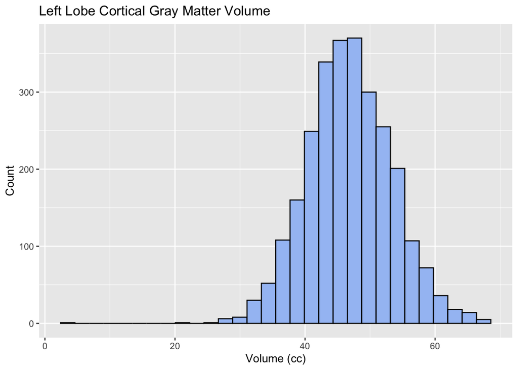

```r
alz3 |>
  ggplot(aes(x = lparcort)) + geom_histogram(color = "black", fill = "#a4c2f4") + labs(title = "Left Lobe Cortical Gray Matter Volume") + xlab('Volume (cc)') + ylab('Count')
```

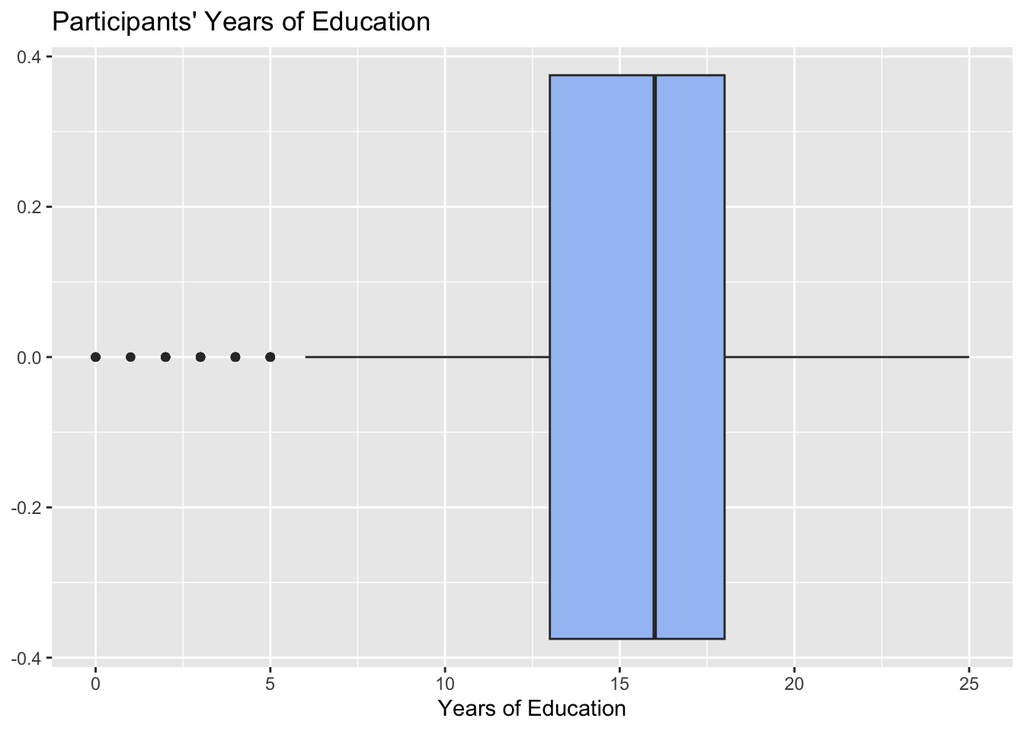

```r
alz3 |>
  ggplot(aes(x = educ)) + geom_boxplot(fill = "#a4c2f4") + labs(title = "Participants' Years of Education") + xlab('Years of Education')
```

```r
alz3 |>
  count(diagnose)
```

```
## # A tibble: 2 × 2
##   diagnose     n
##   <chr>    <int>
## 1 Dementia  1166
## 2 Normal    1534
```

```r
alz3 |>
  count(female)
```

```
## # A tibble: 2 × 2
##   female     n
##   <fct>  <int>
## 1 0       1151
## 2 1       1549
```

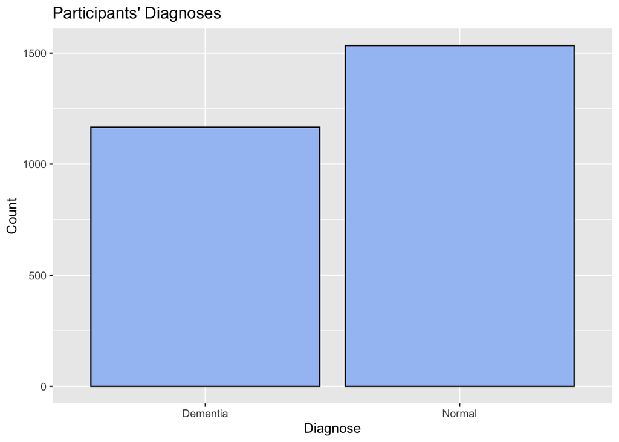

```r
alz3 |>
  ggplot(aes(x = diagnose)) + geom_bar(color = "black", fill = "#a4c2f4") + labs(title = "Participants' Diagnoses") + xlab('Diagnose') + ylab('Count')
```

```r
#alz3 |>
#  ggplot(aes(x = female)) + geom_bar(color = "black", fill = "#a4c2f4") + labs(title = "Participants' Genders") + xlab('Female') + ylab('Count')
```

The majority of participants were female and were diagnosed with showing no signs of having dementia; the average showed most participants had least some post-secondary education. The frontal cortical grey matter was 170 cc with the left parietal cortical averaging 46 cc

**5. Pair each variable with `diagnose` and create an appropriate numerical summary for each pairing. Describe your findings for each pairing. Write a sentence or two to describe your findings.**

```r
alz3 |>
  group_by(diagnose) |>
    summarize(mean(frcort), mean(lparcort), mean(educ), sd(frcort), sd(lparcort))
```

```
## # A tibble: 2 × 6
##   diagnose `mean(frcort)` `mean(lparcort)` `mean(educ)` `sd(frcort)`
##   <chr>             <dbl>            <dbl>        <dbl>        <dbl>
## 1 Dementia           166.             45.4         14.8         23.7
## 2 Normal             174.             47.9         15.6         23.1
## # ℹ 1 more variable: `sd(lparcort)` <dbl>
```

```r
alz3 |>
  group_by(diagnose) |>
    summarize(median(frcort), IQR(frcort),)
```

```
## # A tibble: 2 × 3
##   diagnose `median(frcort)` `IQR(frcort)`
##   <chr>               <dbl>         <dbl>
## 1 Dementia             166.          31.8
## 2 Normal               175.          29.5
```

```r
alz3 |>
  group_by(diagnose) |>
    summarize(median(lparcort), IQR(lparcort),)
```

```
## # A tibble: 2 × 3
##   diagnose `median(lparcort)` `IQR(lparcort)`
##   <chr>                 <dbl>           <dbl>
## 1 Dementia               45.3            8.48
## 2 Normal                 47.6            8.34
```

```r
alz3 |>
  group_by(diagnose) |>
    summarize(median(educ), IQR(educ))
```

```
## # A tibble: 2 × 3
##   diagnose `median(educ)` `IQR(educ)`
##   <chr>             <dbl>       <dbl>
## 1 Dementia             16           6
## 2 Normal               16           4
```

**6. Pair each variable with `diagnose` and create an appropriate graph for each pair. Add labels and color as desired. Add a title. Write a sentence or two to describe your findings for each graph.**

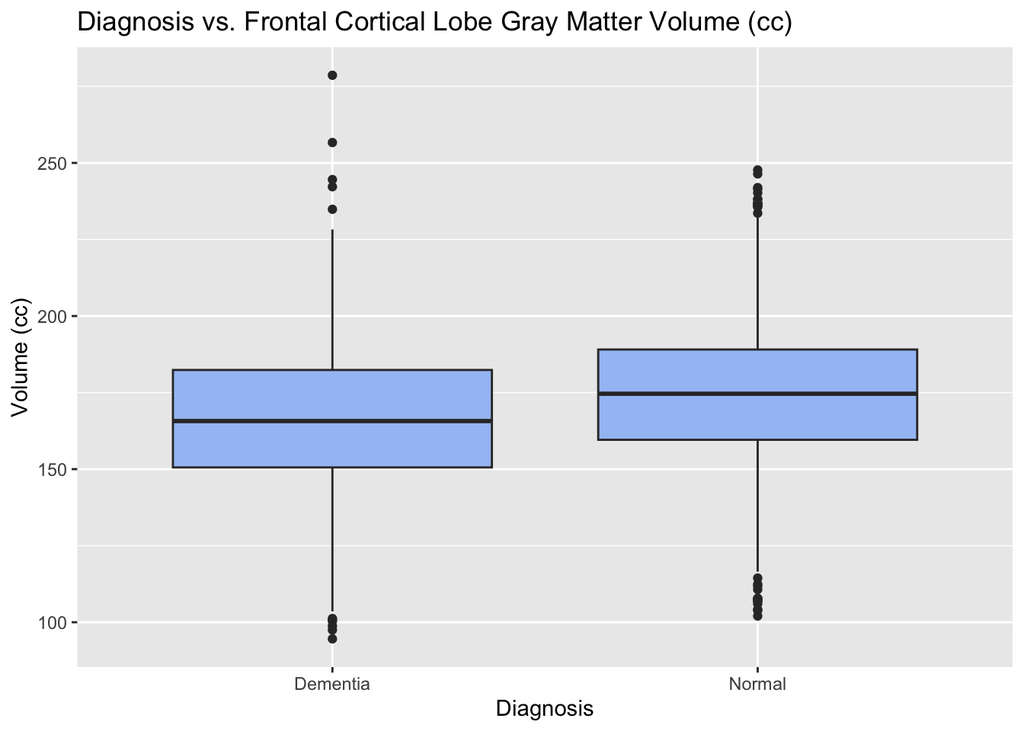

```r
alz3 |>
  ggplot(aes(x = diagnose, y = frcort)) + labs(title = 'Diagnosis vs. Frontal Cortical Lobe Gray Matter Volume (cc)') + geom_boxplot(fill = "#a4c2f4") + xlab('Diagnosis') + ylab('Volume (cc)')
```

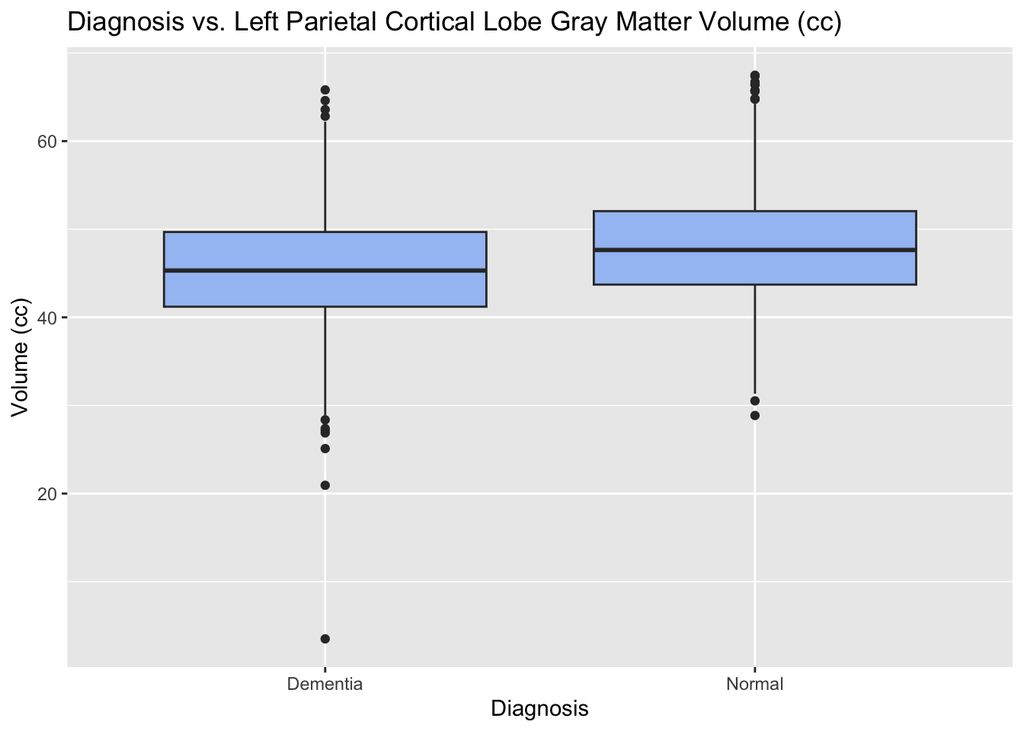

```r
alz3 |>
  ggplot(aes(x = diagnose, y = lparcort)) + labs(title = 'Diagnosis vs. Left Parietal Cortical Lobe Gray Matter Volume (cc)') + geom_boxplot(fill = "#a4c2f4") + xlab('Diagnosis') + ylab('Volume (cc)')
```

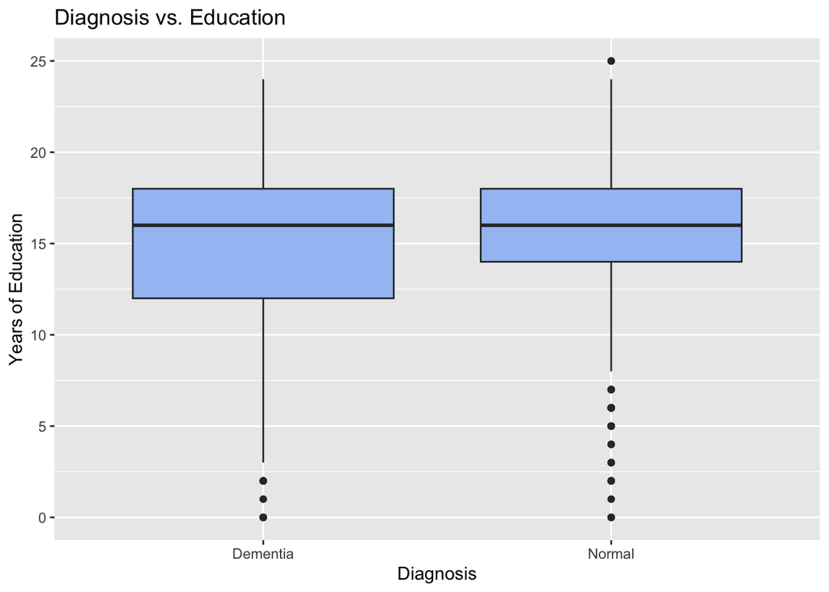

```r
alz3 |>
  ggplot(aes(x = diagnose, y = educ)) + labs(title = 'Diagnosis vs. Education') + geom_boxplot(fill = "#a4c2f4") + xlab('Diagnosis') + ylab('Years of Education')
```

**7. Explore the variables in groups of 3 by creating appropriate numerical summaries or graphs. You are welcome to use filtering or grouping here. Describe your findings.**

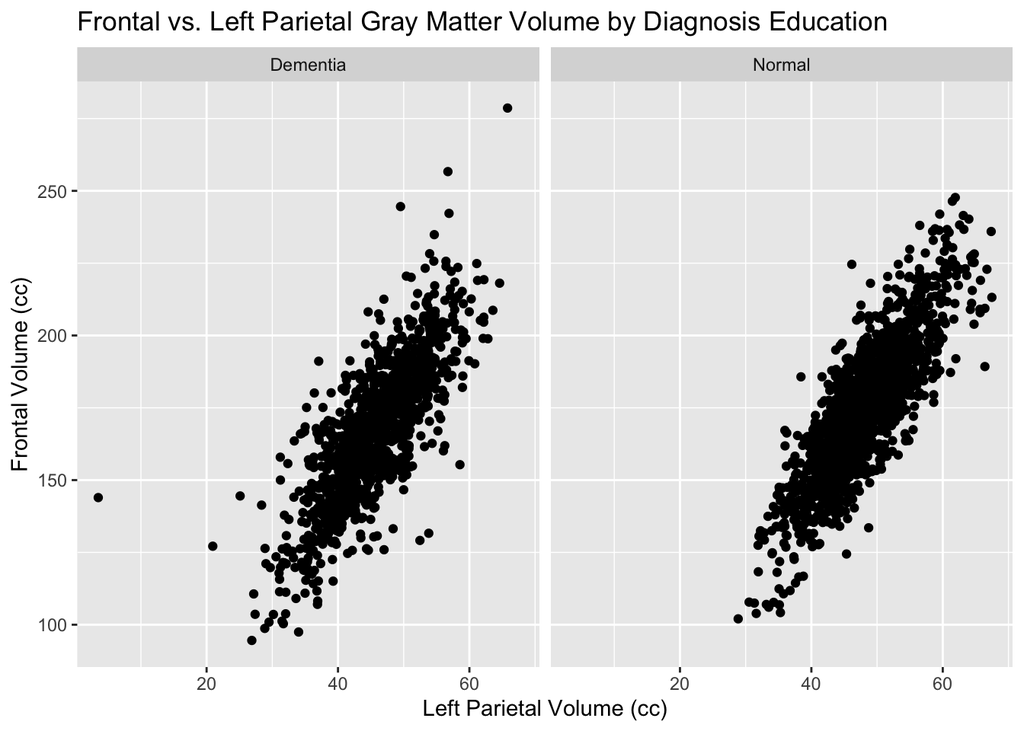

```r
alz3 |>
  ggplot(aes(x = lparcort, y = frcort)) + geom_point() +
  facet_grid(cols = vars(diagnose)) +
  labs(title = "Frontal vs. Left Parietal Gray Matter Volume by Diagnosis Education", x = "Left Parietal Volume (cc)", y = "Frontal Volume (cc)")
```

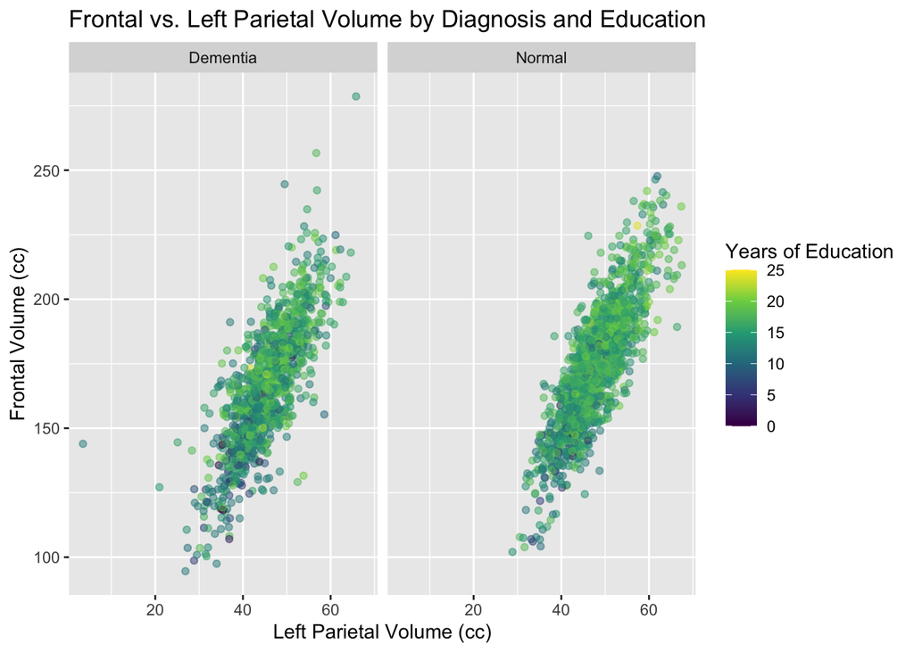

```r
alz3 |>
  ggplot(aes(x = lparcort, y = frcort, color = educ)) +
  geom_point(alpha = 0.5) +
  scale_color_viridis_c() +
  facet_grid(cols = vars(diagnose)) +
  labs(title = "Frontal vs. Left Parietal Volume by Diagnosis and Education",
       x = "Left Parietal Volume (cc)",
       y = "Frontal Volume (cc)",
       color = "Years of Education")
```

**8. Site here any resources that you used, including PDF presentation and csv file. Use MLA if possible.**

Ren, Y (2022) Data Analysis for Alzheimer’s Disease *Stark Lab and Shahbaba Group*

csv file from: https://www.naccdata.org/about-nacc-data/data-summary-tables/

**APA preferred**

## Inferential Analysis

```r
t.test(frcort ~ diagnose, data = alz3)
```

```
##
##  Welch Two Sample t-test
##
## data:  frcort by diagnose
## t = -9.0333, df = 2470.7, p-value < 2.2e-16
## alternative hypothesis: true difference in means between group Dementia and group Normal is not equal to 0
## 95 percent confidence interval:
##  -10.019686  -6.445461
## sample estimates:
## mean in group Dementia   mean in group Normal
##               166.2500               174.4825
```

```r
t.test(lparcort ~ diagnose, data = alz3)
```

```
##
##  Welch Two Sample t-test
##
## data:  lparcort by diagnose
## t = -10.212, df = 2453.6, p-value < 2.2e-16
## alternative hypothesis: true difference in means between group Dementia and group Normal is not equal to 0
## 95 percent confidence interval:
##  -3.049312 -2.066853
## sample estimates:
## mean in group Dementia   mean in group Normal
##               45.37003               47.92811
```

```r
alz3 <- alz3 |>
  mutate(educ_group = case_when(
    educ < 12 ~ "Less than HS",
    educ < 16 ~ "HS to Some College",
    TRUE ~ "Bachelor's or Higher"
  ))
alz3
```

```
## # A tibble: 2,700 × 8
##    id      frcort diagnose lparcort diagnosis female  educ educ_group
##    <chr>    <dbl> <chr>       <dbl> <fct>     <fct>  <dbl> <chr>
##  1 S060833   161. Normal       46.7 0         0         12 HS to Some College
##  2 S932623   188. Normal       43.1 0         1         16 Bachelor's or Higher
##  3 S755478   163. Normal       40.1 0         1         18 Bachelor's or Higher
##  4 S852291   165. Normal       46.1 0         1         20 Bachelor's or Higher
##  5 S011143   149. Dementia     40.3 1         0         14 HS to Some College
##  6 S069106   140. Normal       43.0 0         1         16 Bachelor's or Higher
##  7 S283729   195. Normal       48.7 0         1         16 Bachelor's or Higher
##  8 S122622   164. Dementia     46.8 2         0         17 Bachelor's or Higher
##  9 S153676   108. Normal       30.5 0         1         18 Bachelor's or Higher
## 10 S297075   191. Dementia     51.4 2         0         13 HS to Some College
## # ℹ 2,690 more rows
```

```r
cont_tbl <- table(alz3$educ_group, alz3$diagnose)
addmargins(cont_tbl)
```

```
##
##                        Dementia Normal  Sum
##   Bachelor's or Higher      624    961 1585
##   HS to Some College        435    504  939
##   Less than HS              107     69  176
##   Sum                      1166   1534 2700
```

```r
chisq.test(cont_tbl, correct = FALSE)$expected
```

```
##
##                         Dementia    Normal
##   Bachelor's or Higher 684.48519 900.51481
##   HS to Some College   405.50889 533.49111
##   Less than HS          76.00593  99.99407
```

```r
prop.table(cont_tbl, margin = 1)
```

```
##
##                         Dementia    Normal
##   Bachelor's or Higher 0.3936909 0.6063091
##   HS to Some College   0.4632588 0.5367412
##   Less than HS         0.6079545 0.3920455
```

```r
chisq.test(cont_tbl, correct = FALSE)
```

```
##
##  Pearson's Chi-squared test
##
## data:  cont_tbl
## X-squared = 35.428, df = 2, p-value = 2.027e-08
```

## Regression Models

```r
#glimpse(alz3)
alz4 <- alz3 |>
  mutate(diagnose = diagnose == "Dementia")

# example for residual comparison
alz3 |>
  filter(lparcort == 50)
```

```
## # A tibble: 1 × 8
##   id      frcort diagnose lparcort diagnosis female  educ educ_group
##   <chr>    <dbl> <chr>       <dbl> <fct>     <fct>  <dbl> <chr>
## 1 S368901   183. Normal         50 0         1         14 HS to Some College
```

```r
model_fr = lm(frcort ~ lparcort + educ + diagnose, data = alz4)
model_fr
```

```
##
## Call:
## lm(formula = frcort ~ lparcort + educ + diagnose, data = alz4)
##
## Coefficients:
##  (Intercept)      lparcort          educ  diagnoseTRUE
##      27.1114        2.8637        0.6468       -0.3723
```

```r
glance(model_fr)$adj.r.squared
```

```
## [1] 0.6741272
```

```r
rmse(model_fr, alz4)
```

```
## [1] 13.52784
```

```r
#glimpse(alz3)
#alz5 <- alz3 |>
#  mutate(diagnose_binary = ifelse(diagnose == "Dementia", 1, 0))

model_d = glm(diagnose ~ frcort + lparcort + educ, data = alz4, family = "binomial")
model_d
```

```
##
## Call:  glm(formula = diagnose ~ frcort + lparcort + educ, family = "binomial",
##     data = alz4)
##
## Coefficients:
## (Intercept)       frcort     lparcort         educ
##    3.076831    -0.001914    -0.050891    -0.042693
##
## Degrees of Freedom: 2699 Total (i.e. Null);  2696 Residual
## Null Deviance:       3693
## Residual Deviance: 3575  AIC: 3583
```

```r
exp(-0.34) / (1 + exp(-0.34))
```

```
## [1] 0.4158095
```